# Lab10

```python
import warnings
warnings.filterwarnings('ignore')
import tensorflow as tf
from tensorflow import keras
from tensorflow.keras import layers
from keras.preprocessing import image
import matplotlib.pyplot as plt
import numpy as np
```

```python
import os
import shutil
import pathlib

# Set path to the dataset
train_data = pathlib.Path('/Users/aerishgaba/Downloads/archive/train')
test_data = pathlib.Path('/Users/aerishgaba/Downloads/archive/test')
valid_data = pathlib.Path('/Users/aerishgaba/Downloads/archive/valid')

img_count = {}

# Finding the top 3 classes
for species in os.listdir(train_data):
    path_species = os.path.join(train_data, species)
    if os.path.isdir(path_species):
        img_count[species] = len(os.listdir(path_species))

top_classes = sorted(img_count, key=img_count.get, reverse=True)[:3]
print("Top 3 classes with the highest number of images:", top_classes)

# Removing the other classes from the dataset
directories_to_remove = []

files = [train_data, test_data, valid_data]
for file in files:
    for species in os.listdir(file):
        if species not in top_classes:
            path_species = os.path.join(file, species)
            if os.path.isdir(path_species):
                # Check if the directory is empty, and if not, remove its contents
                if os.listdir(path_species):
                    shutil.rmtree(path_species)  # Remove directory and its contents
                else:
                    directories_to_remove.append(path_species)

# Remove empty directories
for directory in directories_to_remove:
    os.rmdir(directory)
```

```
Top 3 classes with the highest number of images: ['RUFOUS TREPE', 'HOUSE FINCH', 'OVENBIRD']
```

***Data Augmentation***

```python
from tensorflow.keras.preprocessing.image import ImageDataGenerator

# Data augmentation
train_datagen = ImageDataGenerator(rescale=1./255,
                                   rotation_range=40,
                                   width_shift_range=0.2,
                                   height_shift_range=0.2,
                                   shear_range=0.2,
                                   horizontal_flip=True,
                                   fill_mode='nearest')

test_datagen = ImageDataGenerator(rescale=1./255)

# Creating the training, validation and test generators
train_generator = train_datagen.flow_from_directory(train_data,
                                                    target_size=(150, 150),
                                                    batch_size=20,
                                                    class_mode='categorical')

valid_generator = test_datagen.flow_from_directory(valid_data,
                                                    target_size=(150, 150),
                                                    batch_size=20,
                                                    class_mode='categorical')

test_generator = test_datagen.flow_from_directory(test_data,
                                                    target_size=(150, 150),
                                                    batch_size=20,
                                                    class_mode='categorical')

# Printing the number of images increased after data augmentation
print("Number of training images:", len(train_generator.filenames))
print("Number of validation images:", len(valid_generator.filenames))
print("Number of testing images:", len(test_generator.filenames))
```

```
Found 744 images belonging to 3 classes.
Found 15 images belonging to 3 classes.
Found 15 images belonging to 3 classes.
Number of training images: 744
Number of validation images: 15
Number of testing images: 15
```

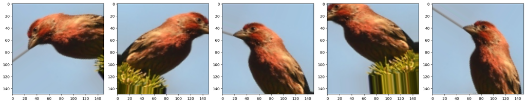

```python
# Visualizing the augmented images
augmented_images = [train_generator[0][0][0] for i in range(5)]
fig, axes = plt.subplots(1, 5, figsize=(20,20))
axes = axes.flatten()
for img, ax in zip(augmented_images, axes):
    ax.imshow(img)
plt.tight_layout()
plt.show()
```

**Fine Tuning the VGG16 Model pre-trained on imagenet**

```python
import ssl
ssl._create_default_https_context = ssl._create_unverified_context
from tensorflow.keras.applications import VGG16
from tensorflow.keras.models import Model
from tensorflow.keras.layers import Dense, GlobalAveragePooling2D
from tensorflow.keras.optimizers.legacy import Adam

# Load pre-trained VGG16 model without including top fully connected layers
base_model = VGG16(weights='imagenet', include_top=False, input_shape=(224,224,3))

# Freeze the convolutional layers to prevent updating their weights during training
for layer in base_model.layers:
    layer.trainable = False

# Add custom classification layers
x = base_model.output
x = GlobalAveragePooling2D()(x) # Global average pooling layer
x = Dense(256, activation='relu')(x) # Fully connected layer with 256 hidden units
x = layers.Dropout(0.5)(x) # Dropout layer with 0.5 dropout rate
x = layers.BatchNormalization()(x) # Batch normalization layer
x = Dense(128, activation='relu')(x) # Fully connected layer with 128 hidden units
x = layers.BatchNormalization()(x) # Batch normalization layer
predictions = Dense(3, activation='softmax')(x) # Softmax for multiclass classification

# Create the final model
model = Model(inputs=base_model.input, outputs=predictions)

# Compile the model
model.compile(optimizer=Adam(lr=0.0004),  # Adam optimizer with learning rate of 0.0004
              loss='categorical_crossentropy',
              metrics=['accuracy'])

# Train the model using train_generator (your data generator)
model.fit(train_generator, epochs=10, validation_data=valid_generator)
```

```
<keras.src.callbacks.History at 0x4c0733790>
```

```python
model.summary()
```

```
Model: "model_35"
_________________________________________________________________
 Layer (type)                Output Shape              Param #
=================================================================
 input_39 (InputLayer)       [(None, 224, 224, 3)]     0

 block1_conv1 (Conv2D)       (None, 224, 224, 64)      1792

 block1_conv2 (Conv2D)       (None, 224, 224, 64)      36928

 block1_pool (MaxPooling2D)  (None, 112, 112, 64)      0

 block2_conv1 (Conv2D)       (None, 112, 112, 128)     73856

 block2_conv2 (Conv2D)       (None, 112, 112, 128)     147584

 block2_pool (MaxPooling2D)  (None, 56, 56, 128)       0

 block3_conv1 (Conv2D)       (None, 56, 56, 256)       295168

 block3_conv2 (Conv2D)       (None, 56, 56, 256)       590080

 block3_conv3 (Conv2D)       (None, 56, 56, 256)       590080

 block3_pool (MaxPooling2D)  (None, 28, 28, 256)       0

 block4_conv1 (Conv2D)       (None, 28, 28, 512)       1180160

 block4_conv2 (Conv2D)       (None, 28, 28, 512)       2359808

 block4_conv3 (Conv2D)       (None, 28, 28, 512)       2359808

 block4_pool (MaxPooling2D)  (None, 14, 14, 512)       0

 block5_conv1 (Conv2D)       (None, 14, 14, 512)       2359808

 block5_conv2 (Conv2D)       (None, 14, 14, 512)       2359808

 block5_conv3 (Conv2D)       (None, 14, 14, 512)       2359808

```

[output cut: 9 more lines]

```
 batch_normalization_16 (Ba  (None, 256)               1024
 tchNormalization)

 dense_88 (Dense)            (None, 128)               32896

 batch_normalization_17 (Ba  (None, 128)               512
 tchNormalization)

 dense_89 (Dense)            (None, 3)                 387

=================================================================
Total params: 14880835 (56.77 MB)
Trainable params: 165379 (646.01 KB)
Non-trainable params: 14715456 (56.14 MB)
_________________________________________________________________
```

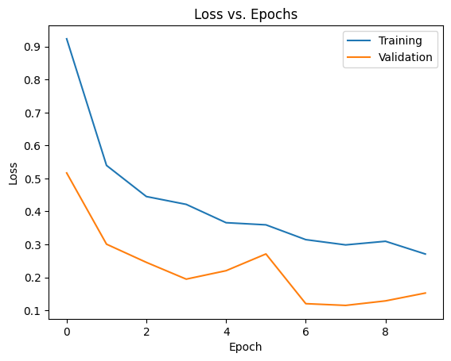

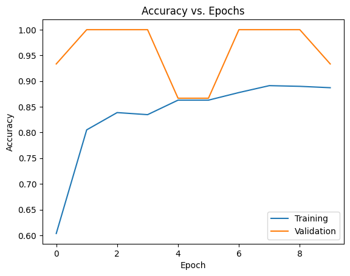

```python
# Visualizing Loss on training and validation data
plt.plot(model.history.history['loss'])
plt.plot(model.history.history['val_loss'])
plt.title('Loss vs. Epochs')
plt.ylabel('Loss')
plt.xlabel('Epoch')
plt.legend(['Training', 'Validation'], loc='upper right')
plt.show()

# Visualizing Accuracy on training and validation data
plt.plot(model.history.history['accuracy'])
plt.plot(model.history.history['val_accuracy'])
plt.title('Accuracy vs. Epochs')
plt.ylabel('Accuracy')
plt.xlabel('Epoch')
plt.legend(['Training', 'Validation'], loc='lower right')
plt.show()
```

**Assesing Model Performance**

```python
# Evaluate the model on the test data using `evaluate`
print("Evaluate on test data")
results = model.evaluate(test_generator)
print("test loss, test acc:", results)
```

```
Evaluate on test data
test loss, test acc: [0.034100815653800964, 1.0]
```

```python
from sklearn.metrics import classification_report, confusion_matrix, accuracy_score

# Assuming you have a test generator for evaluation (test_generator)
# Get predictions for the test set
predictions = model.predict(test_generator)
predicted_classes = np.argmax(predictions, axis=1)

# Get true labels
true_classes = test_generator.classes

# Calculate accuracy
accuracy = accuracy_score(true_classes, predicted_classes)
print(f"Accuracy: {accuracy}")

# Generate confusion matrix
conf_matrix = confusion_matrix(true_classes, predicted_classes)
print("Confusion Matrix:")
print(conf_matrix)

# Classification report with precision, recall, F1-score
class_report = classification_report(true_classes, predicted_classes)
print("Classification Report:")
print(class_report)
```

```
Accuracy: 0.6
Confusion Matrix:
[[3 2 0]
 [0 3 2]
 [2 0 3]]
Classification Report:
              precision    recall  f1-score   support

           0       0.60      0.60      0.60         5
           1       0.60      0.60      0.60         5
           2       0.60      0.60      0.60         5

    accuracy                           0.60        15
   macro avg       0.60      0.60      0.60        15
weighted avg       0.60      0.60      0.60        15
```

The balanced precision, recall, and F1-score across all classes indicate that the model has learned to differentiate between classes more effectively after fine-tuning as tried various tunings and got some bad numbers ranging from 0.266, 0.33, 0.4, 0.44 and so on .  
The accuracy improvement suggests that the model is now making more accurate predictions overall.

```
Number of misclassified images: 6
```

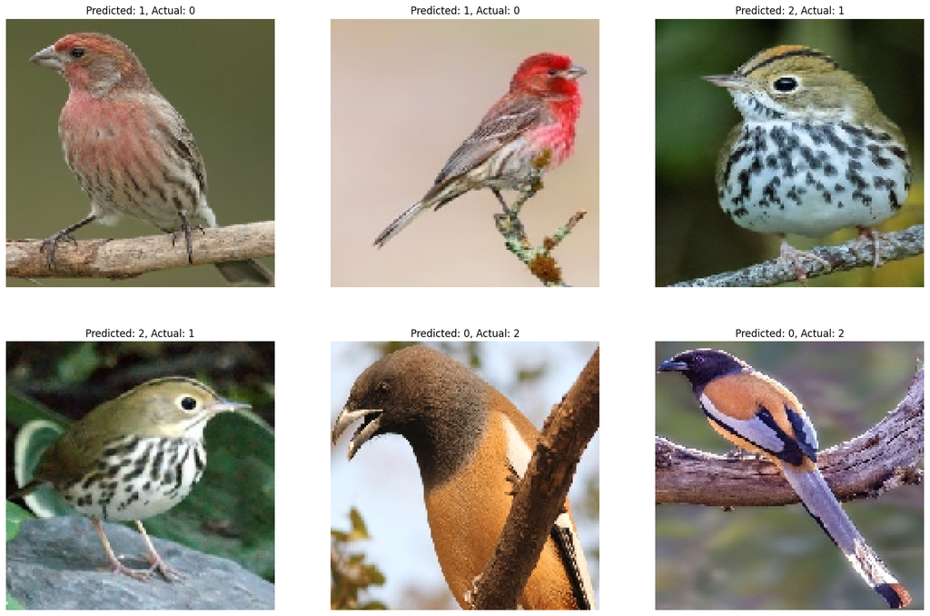

```python
# Visualizing the misclassified images
misclassified_idx = np.where(predicted_classes != true_classes)[0]
print("Number of misclassified images:", len(misclassified_idx))

# Getting the misclassified images
misclassified_images = []
for i in misclassified_idx:
    misclassified_images.append(test_generator.filenames[i])

# Plotting the misclassified images with their predicted and actual labels
plt.figure(figsize=(20, 20))
for i in range(0, 6):
    plt.subplot(3, 3, i+1)
    img = image.load_img(os.path.join(test_data, misclassified_images[i]), target_size=(150, 150))
    plt.imshow(img)
    plt.title("Predicted: {}, Actual: {}".format(predicted_classes[misclassified_idx[i]], true_classes[misclassified_idx[i]]))
    plt.axis('off')
plt.show()
```

```python
# Printing the class labels for the top 3 classes
print("Class labels:", test_generator.class_indices)
```

```
Class labels: {'HOUSE FINCH': 0, 'OVENBIRD': 1, 'RUFOUS TREPE': 2}
```

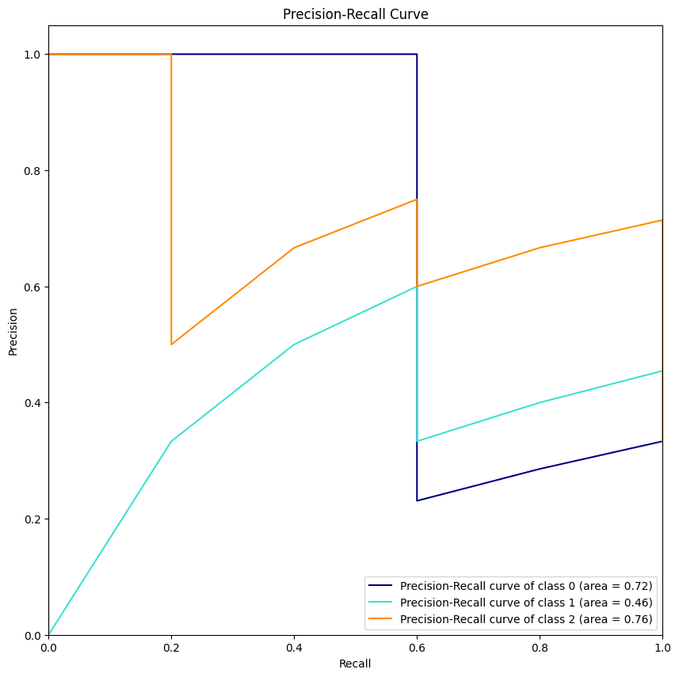

```python
# Plotting the Precision-Recall curve and calculating the AUC
from sklearn.metrics import precision_recall_curve
from sklearn.metrics import average_precision_score

# Compute Precision-Recall and plot curve
precision = dict()
recall = dict()
average_precision = dict()
for i in range(n_classes):
    precision[i], recall[i], _ = precision_recall_curve(y_true[:, i], predictions[:, i])
    average_precision[i] = average_precision_score(y_true[:, i], predictions[:, i])

# Plot Precision-Recall curve for each class
plt.figure(figsize=(10,10))
colors = ['navy', 'turquoise', 'darkorange']
for i, color in zip(range(n_classes), colors):
    plt.plot(recall[i], precision[i], color=color,
                label='Precision-Recall curve of class {0} (area = {1:0.2f})'
                ''.format(i, average_precision[i]))

plt.xlim([0.0, 1.0])
plt.ylim([0.0, 1.05])
plt.xlabel('Recall')
plt.ylabel('Precision')
plt.title('Precision-Recall Curve')
plt.legend(loc="lower right")
plt.show()
```

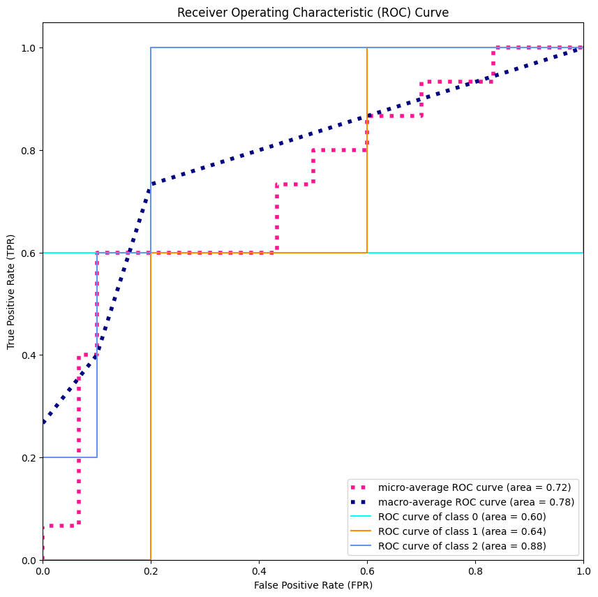

```python
# Plotting the ROC curve and calculating the AUC
from sklearn.metrics import roc_curve, auc
from sklearn.preprocessing import label_binarize
from scipy import interp

# Binarize the true labels
y_true = label_binarize(true_classes, classes=[0, 1, 2])

# Compute ROC curve and ROC area for each class
fpr = dict()
tpr = dict()
roc_auc = dict()
n_classes = 3
for i in range(n_classes):
    fpr[i], tpr[i], _ = roc_curve(y_true[:, i], predictions[:, i])
    roc_auc[i] = auc(fpr[i], tpr[i])

# Compute micro-average ROC curve and ROC area
fpr["micro"], tpr["micro"], _ = roc_curve(y_true.ravel(), predictions.ravel())
roc_auc["micro"] = auc(fpr["micro"], tpr["micro"])

# Aggregate all false positive rates
all_fpr = np.unique(np.concatenate([fpr[i] for i in range(n_classes)]))

# Then interpolate all ROC curves at this points
mean_tpr = np.zeros_like(all_fpr)
for i in range(n_classes):
    mean_tpr += interp(all_fpr, fpr[i], tpr[i])

# Finally average it and compute AUC
mean_tpr /= n_classes

# Compute macro-average ROC
fpr["macro"] = all_fpr
tpr["macro"] = mean_tpr
roc_auc["macro"] = auc(fpr["macro"], tpr["macro"])

# Plot all ROC curves
plt.figure(figsize=(10,10))
plt.plot(fpr["micro"], tpr["micro"],
         label='micro-average ROC curve (area = {0:0.2f})'
               ''.format(roc_auc["micro"]),
         color='deeppink', linestyle=':', linewidth=4)

plt.plot(fpr["macro"], tpr["macro"],
            label='macro-average ROC curve (area = {0:0.2f})'
                ''.format(roc_auc["macro"]),
            color='navy', linestyle=':', linewidth=4)

colors = ['aqua', 'darkorange', 'cornflowerblue']
for i, color in zip(range(n_classes), colors):
    plt.plot(fpr[i], tpr[i], color=color,
                label='ROC curve of class {0} (area = {1:0.2f})'
                ''.format(i, roc_auc[i]))

plt.xlim([0.0, 1.0])
plt.ylim([0.0, 1.05])
plt.xlabel('False Positive Rate (FPR)')
plt.ylabel('True Positive Rate (TPR)')
plt.title('Receiver Operating Characteristic (ROC) Curve')
plt.legend(loc="lower right")
plt.show()
```

Micro-averaged ROC-AUC: Indicates the area under the micro-averaged ROC curve, considering the aggregate true positives and false positives across all classes.  
Macro-averaged ROC-AUC: Represents the average of the ROC-AUC values calculated independently for each class.

**Micro-averaged ROC: Represents the overall ROC curve by considering each prediction as an individual data point, aggregating true positives and false positives across all classes.**  
**Macro-averaged ROC: Calculates the ROC curve for each class independently and then averages these curves to obtain the macro ROC.**